# Woods_Moneyball_2

```r
library(dplyr)
library(flux)
library(ggplot2)
library(gridExtra)
library(knitr)
library(rockchalk)
library(tidyverse)
library(ggthemes)
library(ggpubr)
library(RColorBrewer)
```

```r
setwd("C:/Users/Swood/OneDrive/Northwestern/410 Supervised Learning")
```

```r
mydata <- read.csv("moneyball_train.csv")
```

```r
head(mydata)
```

|  | X | INDEX | TARGET_WINS | TEAM_BATTING_H | TEAM_BATTING_2B | TEAM_BATTING_3B | TEAM_BATTING_HR | TEAM_BATTING_BB | TEAM_BATTING_SO | TEAM_BASERUN_SB | TEAM_BASERUN_CS | TEAM_BATTING_HBP | TEAM_PITCHING_H | TEAM_PITCHING_HR | TEAM_PITCHING_BB | TEAM_PITCHING_SO | TEAM_FIELDING_E | TEAM_FIELDING_DP |
| --- | --- | --- | --- | --- | --- | --- | --- | --- | --- | --- | --- | --- | --- | --- | --- | --- | --- | --- |
| 1 | 0 | 1 | 39 | 1445 | 194 | 39 | 13 | 143 | 842 | NA | NA | NA | 9364 | 84 | 927 | 5456 | 1011 | NA |
| 2 | 1 | 2 | 70 | 1339 | 219 | 22 | 190 | 685 | 1075 | 37 | 28 | NA | 1347 | 191 | 689 | 1082 | 193 | 155 |
| 3 | 2 | 3 | 86 | 1377 | 232 | 35 | 137 | 602 | 917 | 46 | 27 | NA | 1377 | 137 | 602 | 917 | 175 | 153 |
| 4 | 3 | 4 | 70 | 1387 | 209 | 38 | 96 | 451 | 922 | 43 | 30 | NA | 1396 | 97 | 454 | 928 | 164 | 156 |
| 5 | 4 | 5 | 82 | 1297 | 186 | 27 | 102 | 472 | 920 | 49 | 39 | NA | 1297 | 102 | 472 | 920 | 138 | 168 |
| 6 | 5 | 6 | 75 | 1279 | 200 | 36 | 92 | 443 | 973 | 107 | 59 | NA | 1279 | 92 | 443 | 973 | 123 | 149 |

### EDA and Data Preparation

```r
str(mydata)
```

```
'data.frame':   2276 obs. of  18 variables:
 $ X               : int  0 1 2 3 4 5 6 7 8 9 ...
 $ INDEX           : num  1 2 3 4 5 6 7 8 11 12 ...
 $ TARGET_WINS     : num  39 70 86 70 82 75 80 85 86 76 ...
 $ TEAM_BATTING_H  : num  1445 1339 1377 1387 1297 ...
 $ TEAM_BATTING_2B : num  194 219 232 209 186 200 179 171 197 213 ...
 $ TEAM_BATTING_3B : num  39 22 35 38 27 36 54 37 40 18 ...
 $ TEAM_BATTING_HR : num  13 190 137 96 102 92 122 115 114 96 ...
 $ TEAM_BATTING_BB : num  143 685 602 451 472 443 525 456 447 441 ...
 $ TEAM_BATTING_SO : num  842 1075 917 922 920 ...
 $ TEAM_BASERUN_SB : num  NA 37 46 43 49 107 80 40 69 72 ...
 $ TEAM_BASERUN_CS : num  NA 28 27 30 39 59 54 36 27 34 ...
 $ TEAM_BATTING_HBP: num  NA NA NA NA NA NA NA NA NA NA ...
 $ TEAM_PITCHING_H : num  9364 1347 1377 1396 1297 ...
 $ TEAM_PITCHING_HR: num  84 191 137 97 102 92 122 116 114 96 ...
 $ TEAM_PITCHING_BB: num  927 689 602 454 472 443 525 459 447 441 ...
 $ TEAM_PITCHING_SO: num  5456 1082 917 928 920 ...
 $ TEAM_FIELDING_E : num  1011 193 175 164 138 ...
 $ TEAM_FIELDING_DP: num  NA 155 153 156 168 149 186 136 169 159 ...
```

```r
summary(mydata)
```

```
       X              INDEX         TARGET_WINS     TEAM_BATTING_H TEAM_BATTING_2B TEAM_BATTING_3B  TEAM_BATTING_HR
 Min.   :   0.0   Min.   :   1.0   Min.   :  0.00   Min.   : 891   Min.   : 69.0   Min.   :  0.00   Min.   :  0.00
 1st Qu.: 568.8   1st Qu.: 630.8   1st Qu.: 71.00   1st Qu.:1383   1st Qu.:208.0   1st Qu.: 34.00   1st Qu.: 42.00
 Median :1137.5   Median :1270.5   Median : 82.00   Median :1454   Median :238.0   Median : 47.00   Median :102.00
 Mean   :1137.5   Mean   :1268.5   Mean   : 80.79   Mean   :1469   Mean   :241.2   Mean   : 55.25   Mean   : 99.61
 3rd Qu.:1706.2   3rd Qu.:1915.5   3rd Qu.: 92.00   3rd Qu.:1537   3rd Qu.:273.0   3rd Qu.: 72.00   3rd Qu.:147.00
 Max.   :2275.0   Max.   :2535.0   Max.   :146.00   Max.   :2554   Max.   :458.0   Max.   :223.00   Max.   :264.00

 TEAM_BATTING_BB TEAM_BATTING_SO  TEAM_BASERUN_SB TEAM_BASERUN_CS TEAM_BATTING_HBP TEAM_PITCHING_H TEAM_PITCHING_HR
 Min.   :  0.0   Min.   :   0.0   Min.   :  0.0   Min.   :  0.0   Min.   :29.00    Min.   : 1137   Min.   :  0.0
 1st Qu.:451.0   1st Qu.: 548.0   1st Qu.: 66.0   1st Qu.: 38.0   1st Qu.:50.50    1st Qu.: 1419   1st Qu.: 50.0
 Median :512.0   Median : 750.0   Median :101.0   Median : 49.0   Median :58.00    Median : 1518   Median :107.0
 Mean   :501.6   Mean   : 735.6   Mean   :124.8   Mean   : 52.8   Mean   :59.36    Mean   : 1779   Mean   :105.7
 3rd Qu.:580.0   3rd Qu.: 930.0   3rd Qu.:156.0   3rd Qu.: 62.0   3rd Qu.:67.00    3rd Qu.: 1682   3rd Qu.:150.0
 Max.   :878.0   Max.   :1399.0   Max.   :697.0   Max.   :201.0   Max.   :95.00    Max.   :30132   Max.   :343.0
                 NA's   :102      NA's   :131     NA's   :772     NA's   :2085
 TEAM_PITCHING_BB TEAM_PITCHING_SO  TEAM_FIELDING_E  TEAM_FIELDING_DP
 Min.   :   0.0   Min.   :    0.0   Min.   :  65.0   Min.   : 52.0
 1st Qu.: 476.0   1st Qu.:  615.0   1st Qu.: 127.0   1st Qu.:131.0
 Median : 536.5   Median :  813.5   Median : 159.0   Median :149.0
 Mean   : 553.0   Mean   :  817.7   Mean   : 246.5   Mean   :146.4
 3rd Qu.: 611.0   3rd Qu.:  968.0   3rd Qu.: 249.2   3rd Qu.:164.0
 Max.   :3645.0   Max.   :19278.0   Max.   :1898.0   Max.   :228.0
                  NA's   :102                        NA's   :286
```

The min for target wins is 0, which does not seem right.

```r
filter(mydata, TARGET_WINS == 0)
```

| X | INDEX | TARGET_WINS | TEAM_BATTING_H | TEAM_BATTING_2B | TEAM_BATTING_3B | TEAM_BATTING_HR | TEAM_BATTING_BB | TEAM_BATTING_SO | TEAM_BASERUN_SB | TEAM_BASERUN_CS | TEAM_BATTING_HBP | TEAM_PITCHING_H | TEAM_PITCHING_HR | TEAM_PITCHING_BB | TEAM_PITCHING_SO | TEAM_FIELDING_E | TEAM_FIELDING_DP |
| --- | --- | --- | --- | --- | --- | --- | --- | --- | --- | --- | --- | --- | --- | --- | --- | --- | --- |
| 1210 | 1347 | 0 | 891 | 135 | 0 | 0 | 0 | 0 | 0 | 0 | NA | 24057 | 0 | 0 | 0 | 1890 | NA |

This row has many 0 values, so I’m going to drop it.

```r
dim(mydata)
```

```
[1] 2276   18
```

```r
mydata = filter(mydata, TARGET_WINS != 0)

dim(mydata)
```

```
[1] 2275   18
```

```r
summary(mydata)
```

```
       X              INDEX         TARGET_WINS     TEAM_BATTING_H TEAM_BATTING_2B TEAM_BATTING_3B  TEAM_BATTING_HR
 Min.   :   0.0   Min.   :   1.0   Min.   : 12.00   Min.   : 992   Min.   : 69.0   Min.   :  0.00   Min.   :  0.00
 1st Qu.: 568.5   1st Qu.: 630.5   1st Qu.: 71.00   1st Qu.:1383   1st Qu.:208.0   1st Qu.: 34.00   1st Qu.: 42.00
 Median :1137.0   Median :1270.0   Median : 82.00   Median :1454   Median :238.0   Median : 47.00   Median :102.00
 Mean   :1137.5   Mean   :1268.4   Mean   : 80.83   Mean   :1470   Mean   :241.3   Mean   : 55.27   Mean   : 99.66
 3rd Qu.:1706.5   3rd Qu.:1916.0   3rd Qu.: 92.00   3rd Qu.:1538   3rd Qu.:273.0   3rd Qu.: 72.00   3rd Qu.:147.00
 Max.   :2275.0   Max.   :2535.0   Max.   :146.00   Max.   :2554   Max.   :458.0   Max.   :223.00   Max.   :264.00

 TEAM_BATTING_BB TEAM_BATTING_SO  TEAM_BASERUN_SB TEAM_BASERUN_CS  TEAM_BATTING_HBP TEAM_PITCHING_H TEAM_PITCHING_HR
 Min.   : 12.0   Min.   :   0.0   Min.   :  0.0   Min.   :  7.00   Min.   :29.00    Min.   : 1137   Min.   :  0.0
 1st Qu.:451.0   1st Qu.: 548.0   1st Qu.: 66.0   1st Qu.: 38.00   1st Qu.:50.50    1st Qu.: 1419   1st Qu.: 50.0
 Median :512.0   Median : 750.0   Median :101.0   Median : 49.00   Median :58.00    Median : 1518   Median :107.0
 Mean   :501.8   Mean   : 735.9   Mean   :124.8   Mean   : 52.84   Mean   :59.36    Mean   : 1769   Mean   :105.7
 3rd Qu.:580.0   3rd Qu.: 930.0   3rd Qu.:156.0   3rd Qu.: 62.00   3rd Qu.:67.00    3rd Qu.: 1682   3rd Qu.:150.0
 Max.   :878.0   Max.   :1399.0   Max.   :697.0   Max.   :201.00   Max.   :95.00    Max.   :30132   Max.   :343.0
                 NA's   :102      NA's   :131     NA's   :772      NA's   :2084
 TEAM_PITCHING_BB TEAM_PITCHING_SO  TEAM_FIELDING_E  TEAM_FIELDING_DP
 Min.   : 119.0   Min.   :    0.0   Min.   :  65.0   Min.   : 52.0
 1st Qu.: 476.0   1st Qu.:  615.0   1st Qu.: 127.0   1st Qu.:131.0
 Median : 537.0   Median :  814.0   Median : 159.0   Median :149.0
 Mean   : 553.3   Mean   :  818.1   Mean   : 245.8   Mean   :146.4
 3rd Qu.: 611.0   3rd Qu.:  968.0   3rd Qu.: 249.0   3rd Qu.:164.0
 Max.   :3645.0   Max.   :19278.0   Max.   :1898.0   Max.   :228.0
                  NA's   :102                        NA's   :285
```

```r
filter(mydata, TEAM_BATTING_HR == 0)
```

| X | INDEX | TARGET_WINS | TEAM_BATTING_H | TEAM_BATTING_2B | TEAM_BATTING_3B | TEAM_BATTING_HR | TEAM_BATTING_BB | TEAM_BATTING_SO | TEAM_BASERUN_SB | TEAM_BASERUN_CS | TEAM_BATTING_HBP | TEAM_PITCHING_H | TEAM_PITCHING_HR | TEAM_PITCHING_BB | TEAM_PITCHING_SO | TEAM_FIELDING_E | TEAM_FIELDING_DP |
| --- | --- | --- | --- | --- | --- | --- | --- | --- | --- | --- | --- | --- | --- | --- | --- | --- | --- |
| 390 | 433 | 39 | 1620 | 201 | 44 | 0 | 83 | 105 | 74 | 61 | NA | 7093 | 0 | 363 | 460 | 1567 | NA |
| 414 | 459 | 23 | 1458 | 220 | 35 | 0 | 93 | 0 | NA | NA | NA | 16871 | 0 | 1076 | 0 | 1898 | NA |
| 416 | 461 | 44 | 2003 | 272 | 44 | 0 | 125 | 96 | 88 | 22 | NA | 14749 | 0 | 920 | 707 | 1237 | NA |
| 418 | 463 | 71 | 1738 | 217 | 82 | 0 | 157 | 305 | NA | NA | NA | 4772 | 0 | 431 | 837 | 859 | 118 |
| 860 | 953 | 73 | 1685 | 206 | 31 | 0 | 58 | 0 | NA | NA | NA | 4074 | 0 | 140 | 0 | 931 | NA |
| 981 | 1089 | 17 | 1313 | 145 | 34 | 0 | 78 | 162 | 45 | 22 | NA | 7335 | 0 | 436 | 905 | 1553 | NA |
| 1341 | 1494 | 108 | 1188 | 338 | 0 | 0 | 270 | 945 | NA | NA | NA | 16038 | 0 | 3645 | 12758 | 716 | NA |
| 1583 | 1769 | 36 | 1674 | 216 | 54 | 0 | 72 | 72 | 0 | 54 | NA | 30132 | 0 | 1296 | 1296 | 1728 | NA |
| 1824 | 2050 | 14 | 1437 | 148 | 56 | 0 | 56 | 155 | 14 | 7 | NA | 10121 | 0 | 394 | 1092 | 1740 | NA |
| 2014 | 2253 | 34 | 1177 | 171 | 9 | 0 | 119 | 0 | NA | NA | NA | 10035 | 0 | 1015 | 0 | 1279 | NA |

[output cut: 4 more lines]

```r
filter(mydata, TEAM_PITCHING_SO == 0)
```

| X | INDEX | TARGET_WINS | TEAM_BATTING_H | TEAM_BATTING_2B | TEAM_BATTING_3B | TEAM_BATTING_HR | TEAM_BATTING_BB | TEAM_BATTING_SO | TEAM_BASERUN_SB | TEAM_BASERUN_CS | TEAM_BATTING_HBP | TEAM_PITCHING_H | TEAM_PITCHING_HR | TEAM_PITCHING_BB | TEAM_PITCHING_SO | TEAM_FIELDING_E | TEAM_FIELDING_DP |
| --- | --- | --- | --- | --- | --- | --- | --- | --- | --- | --- | --- | --- | --- | --- | --- | --- | --- |
| 297 | 325 | 120 | 2270 | 301 | 132 | 42 | 74 | 0 | NA | NA | NA | 5253 | 97 | 171 | 0 | 1058 | NA |
| 298 | 326 | 146 | 2305 | 322 | 111 | 29 | 64 | 0 | NA | NA | NA | 4727 | 59 | 131 | 0 | 951 | NA |
| 392 | 435 | 65 | 1464 | 147 | 32 | 3 | 94 | 0 | NA | NA | NA | 4312 | 9 | 277 | 0 | 1473 | NA |
| 414 | 459 | 23 | 1458 | 220 | 35 | 0 | 93 | 0 | NA | NA | NA | 16871 | 0 | 1076 | 0 | 1898 | NA |
| 859 | 952 | 77 | 1895 | 244 | 8 | 8 | 93 | 0 | NA | NA | NA | 5203 | 22 | 255 | 0 | 1225 | NA |
| 860 | 953 | 73 | 1685 | 206 | 31 | 0 | 58 | 0 | NA | NA | NA | 4074 | 0 | 140 | 0 | 931 | NA |
| 997 | 1106 | 49 | 1794 | 281 | 58 | 6 | 79 | 0 | NA | NA | NA | 5484 | 18 | 241 | 0 | 1531 | NA |
| 998 | 1107 | 107 | 1725 | 194 | 67 | 4 | 79 | 0 | NA | NA | NA | 3408 | 8 | 156 | 0 | 853 | NA |
| 1344 | 1498 | 24 | 1289 | 145 | 41 | 7 | 45 | 0 | NA | NA | NA | 4443 | 24 | 155 | 0 | 1506 | NA |
| 1348 | 1502 | 105 | 1767 | 249 | 77 | 20 | 95 | 0 | NA | NA | NA | 4404 | 50 | 237 | 0 | 1092 | NA |

[output cut: 9 more lines]

All 19 rows with no pitching strike outs also have no batting strike outs, which should not be related. Removing these rows decreased R2 values for linear models, so I am going to leave them.

```r
colSums(is.na(mydata))
```

```
               X            INDEX      TARGET_WINS   TEAM_BATTING_H  TEAM_BATTING_2B  TEAM_BATTING_3B  TEAM_BATTING_HR
               0                0                0                0                0                0                0
 TEAM_BATTING_BB  TEAM_BATTING_SO  TEAM_BASERUN_SB  TEAM_BASERUN_CS TEAM_BATTING_HBP  TEAM_PITCHING_H TEAM_PITCHING_HR
               0              102              131              772             2084                0                0
TEAM_PITCHING_BB TEAM_PITCHING_SO  TEAM_FIELDING_E TEAM_FIELDING_DP
               0              102                0              285
```

```r
(colMeans(is.na(mydata)))*100
```

```
               X            INDEX      TARGET_WINS   TEAM_BATTING_H  TEAM_BATTING_2B  TEAM_BATTING_3B  TEAM_BATTING_HR
        0.000000         0.000000         0.000000         0.000000         0.000000         0.000000         0.000000
 TEAM_BATTING_BB  TEAM_BATTING_SO  TEAM_BASERUN_SB  TEAM_BASERUN_CS TEAM_BATTING_HBP  TEAM_PITCHING_H TEAM_PITCHING_HR
        0.000000         4.483516         5.758242        33.934066        91.604396         0.000000         0.000000
TEAM_PITCHING_BB TEAM_PITCHING_SO  TEAM_FIELDING_E TEAM_FIELDING_DP
        0.000000         4.483516         0.000000        12.527473
```

I am going to see if adding dummy variable columns for any column with more than 10% NAs has value (1 = NA, 0 = numeric): Team_Baserun_CS, Team_Batting_HBP, Team_Fielding_DP

```r
mydata$TEAM_BASERUN_CS_DummyNA <- ifelse(is.na(mydata$TEAM_BASERUN_CS), 1, 0)

mydata$Team_Batting_HBP_DummyNA <- ifelse(is.na(mydata$TEAM_BATTING_HBP), 1, 0)

mydata$Team_Fielding_DP_DummyNA <- ifelse(is.na(mydata$TEAM_FIELDING_DP), 1, 0)

head(mydata)
```

|  | X | INDEX | TARGET_WINS | TEAM_BATTING_H | TEAM_BATTING_2B | TEAM_BATTING_3B | TEAM_BATTING_HR | TEAM_BATTING_BB | TEAM_BATTING_SO | TEAM_BASERUN_SB | TEAM_BASERUN_CS | TEAM_BATTING_HBP | TEAM_PITCHING_H | TEAM_PITCHING_HR | TEAM_PITCHING_BB | TEAM_PITCHING_SO | TEAM_FIELDING_E | TEAM_FIELDING_DP | TEAM_BASERUN_CS_DummyNA | Team_Batting_HBP_DummyNA | Team_Fielding_DP_DummyNA |
| --- | --- | --- | --- | --- | --- | --- | --- | --- | --- | --- | --- | --- | --- | --- | --- | --- | --- | --- | --- | --- | --- |
| 1 | 0 | 1 | 39 | 1445 | 194 | 39 | 13 | 143 | 842 | NA | NA | NA | 9364 | 84 | 927 | 5456 | 1011 | NA | 1 | 1 | 1 |
| 2 | 1 | 2 | 70 | 1339 | 219 | 22 | 190 | 685 | 1075 | 37 | 28 | NA | 1347 | 191 | 689 | 1082 | 193 | 155 | 0 | 1 | 0 |
| 3 | 2 | 3 | 86 | 1377 | 232 | 35 | 137 | 602 | 917 | 46 | 27 | NA | 1377 | 137 | 602 | 917 | 175 | 153 | 0 | 1 | 0 |
| 4 | 3 | 4 | 70 | 1387 | 209 | 38 | 96 | 451 | 922 | 43 | 30 | NA | 1396 | 97 | 454 | 928 | 164 | 156 | 0 | 1 | 0 |
| 5 | 4 | 5 | 82 | 1297 | 186 | 27 | 102 | 472 | 920 | 49 | 39 | NA | 1297 | 102 | 472 | 920 | 138 | 168 | 0 | 1 | 0 |
| 6 | 5 | 6 | 75 | 1279 | 200 | 36 | 92 | 443 | 973 | 107 | 59 | NA | 1279 | 92 | 443 | 973 | 123 | 149 | 0 | 1 | 0 |

```r
NA
```

```r
aggregate(mydata$TARGET_WINS, list(mydata$TEAM_BASERUN_CS_DummyNA), FUN=mean)
```

| Group.1 | x |
| --- | --- |
| 0 | 80.89953 |
| 1 | 80.68394 |

```r
aggregate(mydata$TARGET_WINS, list(mydata$Team_Batting_HBP_DummyNA), FUN=mean)
```

| Group.1 | x |
| --- | --- |
| 0 | 80.92670 |
| 1 | 80.81718 |

```r
aggregate(mydata$TARGET_WINS, list(mydata$Team_Fielding_DP_DummyNA), FUN=mean)
```

| Group.1 | x |
| --- | --- |
| 0 | 81.00452 |
| 1 | 79.58246 |

With a very small difference in means between groups, I am going to drop any column with more than 10% NA values: Team_Baserun_CS, Team_Batting_HBP, Team_Fielding_DP.

```r
dim(mydata)
```

```
[1] 2275   21
```

```r
df = subset(mydata, select = -c(TEAM_BASERUN_CS, TEAM_BATTING_HBP, TEAM_FIELDING_DP, TEAM_BASERUN_CS_DummyNA, Team_Batting_HBP_DummyNA, Team_Fielding_DP_DummyNA) )

dim(df)
```

```
[1] 2275   15
```

```r
library(corrplot)
corr_mat <- cor(df)

corr_mat
```

```
                            X        INDEX TARGET_WINS TEAM_BATTING_H TEAM_BATTING_2B TEAM_BATTING_3B TEAM_BATTING_HR
X                 1.000000000  0.999973846 -0.02134966    -0.01813047      0.01185895    -0.006237687      0.05204726
INDEX             0.999973846  1.000000000 -0.02093738    -0.01779540      0.01130233    -0.005726872      0.05158905
TARGET_WINS      -0.021349657 -0.020937382  1.00000000     0.38331335      0.28596458     0.139073830      0.17355199
TEAM_BATTING_H   -0.018130470 -0.017795401  0.38331335     1.00000000      0.56146954     0.426084979     -0.00947716
TEAM_BATTING_2B   0.011858950  0.011302333  0.28596458     0.56146954      1.00000000    -0.109498281      0.43450589
TEAM_BATTING_3B  -0.006237687 -0.005726872  0.13907383     0.42608498     -0.10949828     1.000000000     -0.63792589
TEAM_BATTING_HR   0.052047264  0.051589052  0.17355199    -0.00947716      0.43450589    -0.637925892      1.00000000
TEAM_BATTING_BB  -0.026090359 -0.026473020  0.22547152    -0.08023191      0.25286114    -0.292117571      0.51296999
TEAM_BATTING_SO            NA           NA          NA             NA              NA              NA              NA
TEAM_BASERUN_SB            NA           NA          NA             NA              NA              NA              NA
TEAM_PITCHING_H   0.017202707  0.017344709 -0.07914566     0.35166795      0.04192467     0.221393120     -0.25319900
TEAM_PITCHING_HR  0.051508295  0.051100318  0.18632661     0.07011322      0.45364008    -0.570199293      0.96933448
TEAM_PITCHING_BB -0.014980799 -0.015168537  0.11764391     0.08887520      0.17536053    -0.005131897      0.13493092
TEAM_PITCHING_SO           NA           NA          NA             NA              NA              NA              NA
TEAM_FIELDING_E  -0.010053978 -0.009683079 -0.16302210     0.28181926     -0.23086449     0.522514187     -0.58925026
                 TEAM_BATTING_BB TEAM_BATTING_SO TEAM_BASERUN_SB TEAM_PITCHING_H TEAM_PITCHING_HR TEAM_PITCHING_BB
X                    -0.02609036              NA              NA      0.01720271       0.05150829     -0.014980799
INDEX                -0.02647302              NA              NA      0.01734471       0.05110032     -0.015168537
TARGET_WINS           0.22547152              NA              NA     -0.07914566       0.18632661      0.117643912
TEAM_BATTING_H       -0.08023191              NA              NA      0.35166795       0.07011322      0.088875201
TEAM_BATTING_2B       0.25286114              NA              NA      0.04192467       0.45364008      0.175360534
TEAM_BATTING_3B      -0.29211757              NA              NA      0.22139312      -0.57019929     -0.005131897
TEAM_BATTING_HR       0.51296999              NA              NA     -0.25319900       0.96933448      0.134930919
TEAM_BATTING_BB       1.00000000              NA              NA     -0.44830212       0.45843864      0.486354100
TEAM_BATTING_SO               NA               1              NA              NA               NA               NA
TEAM_BASERUN_SB               NA              NA               1              NA               NA               NA
TEAM_PITCHING_H      -0.44830212              NA              NA      1.00000000      -0.13749213      0.365398006
TEAM_PITCHING_HR      0.45843864              NA              NA     -0.13749213       1.00000000      0.220095843
TEAM_PITCHING_BB      0.48635410              NA              NA      0.36539801       0.22009584      1.000000000
TEAM_PITCHING_SO              NA              NA              NA              NA               NA               NA
TEAM_FIELDING_E      -0.65289124              NA              NA      0.66228674      -0.49367650     -0.012462909
                 TEAM_PITCHING_SO TEAM_FIELDING_E
X                              NA    -0.010053978
INDEX                          NA    -0.009683079
TARGET_WINS                    NA    -0.163022098
TEAM_BATTING_H                 NA     0.281819264
TEAM_BATTING_2B                NA    -0.230864491
TEAM_BATTING_3B                NA     0.522514187
TEAM_BATTING_HR                NA    -0.589250264
TEAM_BATTING_BB                NA    -0.652891243
TEAM_BATTING_SO                NA              NA
TEAM_BASERUN_SB                NA              NA
TEAM_PITCHING_H                NA     0.662286737
TEAM_PITCHING_HR               NA    -0.493676504
TEAM_PITCHING_BB               NA    -0.012462909
TEAM_PITCHING_SO                1              NA
TEAM_FIELDING_E                NA     1.000000000
```

I am going to investigate potential linear relationships between remaining columns with NAs before deciding what to do with them.

```r
names(which(colSums(is.na(df))>0))
```

```
[1] "TEAM_BATTING_SO"  "TEAM_BASERUN_SB"  "TEAM_PITCHING_SO"
```

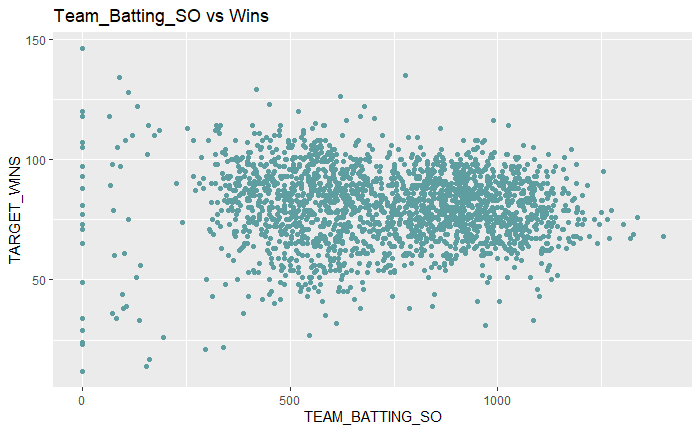

```r
na_cols <- c("TEAM_BATTING_SO", "TEAM_BASERUN_SB", "TEAM_PITCHING_SO")

point1 <- ggplot(data = df) + aes(x = TEAM_BATTING_SO, y = TARGET_WINS) +
    geom_point(color = "cadetblue") + ggtitle("Team_Batting_SO vs Wins") +
    ylab("TARGET_WINS") + xlab("TEAM_BATTING_SO")+
    theme(legend.position = c(), legend.background = element_rect())

point2 <- ggplot(data = df) + aes(x = TEAM_BASERUN_SB, y = TARGET_WINS) +
    geom_point(color = "indianred") + ggtitle("TEAM_BASERUN_SB vs Wins") +
    ylab("TARGET_WINS") + xlab("TEAM_BASERUN_SB")+
    theme(legend.position = c(), legend.background = element_rect())

point3 <- ggplot(data = df) + aes(x = TEAM_PITCHING_SO, y = TARGET_WINS) +
    geom_point(color = "black") + ggtitle("TEAM_PITCHING_SO vs Wins") +
    ylab("TARGET_WINS") + xlab("TTEAM_PITCHING_SO")+
    theme(legend.position = c(), legend.background = element_rect())



point1
```

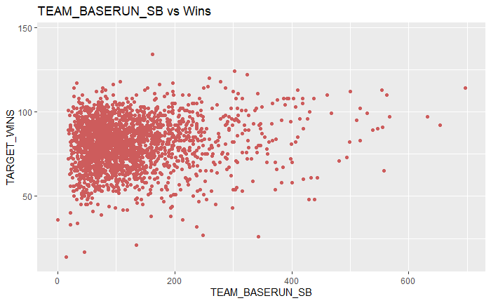

```r
point2
```

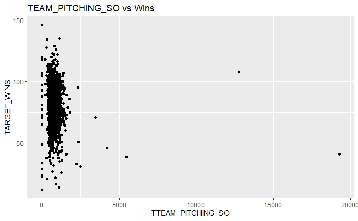

```r
point3
```

None of these fields show strong linear relationships, so I am going to impute with mean values for now.

```r
for(i in 1:ncol(df)) {
  df[ , i][is.na(df[ , i])] <- mean(df[ , i], na.rm=TRUE)
}
```

```r
names(which(colSums(is.na(df))>0))
```

```
character(0)
```

Now I can look at correlations

```r
corr_mat <- cor(df, method = "s")


corr_mat
```

```
                             X         INDEX TARGET_WINS TEAM_BATTING_H TEAM_BATTING_2B TEAM_BATTING_3B TEAM_BATTING_HR
X                 1.0000000000  1.0000000000 -0.01089716    0.001655656      0.02205145    0.0006883045      0.05053816
INDEX             1.0000000000  1.0000000000 -0.01089716    0.001655656      0.02205145    0.0006883045      0.05053816
TARGET_WINS      -0.0108971596 -0.0108971596  1.00000000    0.367711400      0.23648463    0.1224158115      0.15525135
TEAM_BATTING_H    0.0016556564  0.0016556564  0.36771140    1.000000000      0.59560130    0.3284169842      0.06907673
TEAM_BATTING_2B   0.0220514537  0.0220514537  0.23648463    0.595601298      1.00000000   -0.1568763532      0.44315766
TEAM_BATTING_3B   0.0006883045  0.0006883045  0.12241581    0.328416984     -0.15687635    1.0000000000     -0.68040007
TEAM_BATTING_HR   0.0505381648  0.0505381648  0.15525135    0.069076730      0.44315766   -0.6804000716      1.00000000
TEAM_BATTING_BB  -0.0387634924 -0.0387634924  0.23168705    0.073510541      0.27017858   -0.2860669201      0.49286001
TEAM_BATTING_SO   0.0858591785  0.0858591785 -0.07337510   -0.378972132      0.15884959   -0.7192254324      0.69793320
TEAM_BASERUN_SB   0.0603933994  0.0603933994  0.10487042    0.004862706     -0.17698737    0.3673914695     -0.43738236
TEAM_PITCHING_H  -0.0088399301 -0.0088399301  0.21522266    0.756189825      0.28469044    0.5392971706     -0.29879651
TEAM_PITCHING_HR  0.0545155809  0.0545155809  0.16473015    0.107632642      0.45459310   -0.6490504005      0.97884182
TEAM_PITCHING_BB -0.0378439398 -0.0378439398  0.21259504    0.152181457      0.21672381   -0.1009213633      0.28349718
TEAM_PITCHING_SO  0.0812163259  0.0812163259 -0.08916819   -0.356243768      0.10355977   -0.5941466065      0.53531023
TEAM_FIELDING_E  -0.0341497522 -0.0341497522 -0.12037452    0.110008358     -0.37695536    0.7383453554     -0.80965070
                 TEAM_BATTING_BB TEAM_BATTING_SO TEAM_BASERUN_SB TEAM_PITCHING_H TEAM_PITCHING_HR TEAM_PITCHING_BB
X                    -0.03876349      0.08585918     0.060393399     -0.00883993       0.05451558      -0.03784394
INDEX                -0.03876349      0.08585918     0.060393399     -0.00883993       0.05451558      -0.03784394
TARGET_WINS           0.23168705     -0.07337510     0.104870423      0.21522266       0.16473015       0.21259504
TEAM_BATTING_H        0.07351054     -0.37897213     0.004862706      0.75618983       0.10763264       0.15218146
TEAM_BATTING_2B       0.27017858      0.15884959    -0.176987374      0.28469044       0.45459310       0.21672381
TEAM_BATTING_3B      -0.28606692     -0.71922543     0.367391469      0.53929717      -0.64905040      -0.10092136
TEAM_BATTING_HR       0.49286001      0.69793320    -0.437382361     -0.29879651       0.97884182       0.28349718
TEAM_BATTING_BB       1.00000000      0.25936511    -0.180242469     -0.14331017       0.46291557       0.86998146
TEAM_BATTING_SO       0.25936511      1.00000000    -0.149402478     -0.58589427       0.66140087       0.06068822
TEAM_BASERUN_SB      -0.18024247     -0.14940248     1.000000000      0.16745538      -0.42755718      -0.04529406
TEAM_PITCHING_H      -0.14331017     -0.58589427     0.167455376      1.00000000      -0.20682439       0.14086992
TEAM_PITCHING_HR      0.46291557      0.66140087    -0.427557180     -0.20682439       1.00000000       0.31700233
TEAM_PITCHING_BB      0.86998146      0.06068822    -0.045294062      0.14086992       0.31700233       1.00000000
TEAM_PITCHING_SO      0.10755138      0.89938971    -0.054454457     -0.36602702       0.54951023       0.03550826
TEAM_FIELDING_E      -0.42609748     -0.72524456     0.373013081      0.46701178      -0.76732096      -0.18871864
                 TEAM_PITCHING_SO TEAM_FIELDING_E
X                      0.08121633     -0.03414975
INDEX                  0.08121633     -0.03414975
TARGET_WINS           -0.08916819     -0.12037452
TEAM_BATTING_H        -0.35624377      0.11000836
TEAM_BATTING_2B        0.10355977     -0.37695536
TEAM_BATTING_3B       -0.59414661      0.73834536
TEAM_BATTING_HR        0.53531023     -0.80965070
TEAM_BATTING_BB        0.10755138     -0.42609748
TEAM_BATTING_SO        0.89938971     -0.72524456
TEAM_BASERUN_SB       -0.05445446      0.37301308
TEAM_PITCHING_H       -0.36602702      0.46701178
TEAM_PITCHING_HR       0.54951023     -0.76732096
TEAM_PITCHING_BB       0.03550826     -0.18871864
TEAM_PITCHING_SO       1.00000000     -0.53913271
TEAM_FIELDING_E       -0.53913271      1.00000000
```

Some fields are correlated with one another, avoid using both of these fields in a model. For example, TEAM_BATTING_HR AND TEAM_PITCHING_HR.

```r
corr_mat[corr_mat < 0.6] <- ""

corr_mat
```

```
                 X   INDEX TARGET_WINS TEAM_BATTING_H      TEAM_BATTING_2B TEAM_BATTING_3B     TEAM_BATTING_HR
X                "1" "1"   ""          ""                  ""              ""                  ""
INDEX            "1" "1"   ""          ""                  ""              ""                  ""
TARGET_WINS      ""  ""    "1"         ""                  ""              ""                  ""
TEAM_BATTING_H   ""  ""    ""          "1"                 ""              ""                  ""
TEAM_BATTING_2B  ""  ""    ""          ""                  "1"             ""                  ""
TEAM_BATTING_3B  ""  ""    ""          ""                  ""              "1"                 ""
TEAM_BATTING_HR  ""  ""    ""          ""                  ""              ""                  "1"
TEAM_BATTING_BB  ""  ""    ""          ""                  ""              ""                  ""
TEAM_BATTING_SO  ""  ""    ""          ""                  ""              ""                  "0.697933198173555"
TEAM_BASERUN_SB  ""  ""    ""          ""                  ""              ""                  ""
TEAM_PITCHING_H  ""  ""    ""          "0.756189825312303" ""              ""                  ""
TEAM_PITCHING_HR ""  ""    ""          ""                  ""              ""                  "0.978841822344351"
TEAM_PITCHING_BB ""  ""    ""          ""                  ""              ""                  ""
TEAM_PITCHING_SO ""  ""    ""          ""                  ""              ""                  ""
TEAM_FIELDING_E  ""  ""    ""          ""                  ""              "0.738345355422879" ""
                 TEAM_BATTING_BB     TEAM_BATTING_SO     TEAM_BASERUN_SB TEAM_PITCHING_H     TEAM_PITCHING_HR
X                ""                  ""                  ""              ""                  ""
INDEX            ""                  ""                  ""              ""                  ""
TARGET_WINS      ""                  ""                  ""              ""                  ""
TEAM_BATTING_H   ""                  ""                  ""              "0.756189825312303" ""
TEAM_BATTING_2B  ""                  ""                  ""              ""                  ""
TEAM_BATTING_3B  ""                  ""                  ""              ""                  ""
TEAM_BATTING_HR  ""                  "0.697933198173555" ""              ""                  "0.978841822344351"
TEAM_BATTING_BB  "1"                 ""                  ""              ""                  ""
TEAM_BATTING_SO  ""                  "1"                 ""              ""                  "0.661400869119902"
TEAM_BASERUN_SB  ""                  ""                  "1"             ""                  ""
TEAM_PITCHING_H  ""                  ""                  ""              "1"                 ""
TEAM_PITCHING_HR ""                  "0.661400869119902" ""              ""                  "1"
TEAM_PITCHING_BB "0.869981463019962" ""                  ""              ""                  ""
TEAM_PITCHING_SO ""                  "0.899389707051171" ""              ""                  ""
TEAM_FIELDING_E  ""                  ""                  ""              ""                  ""
                 TEAM_PITCHING_BB    TEAM_PITCHING_SO    TEAM_FIELDING_E
X                ""                  ""                  ""
INDEX            ""                  ""                  ""
TARGET_WINS      ""                  ""                  ""
TEAM_BATTING_H   ""                  ""                  ""
TEAM_BATTING_2B  ""                  ""                  ""
TEAM_BATTING_3B  ""                  ""                  "0.738345355422879"
TEAM_BATTING_HR  ""                  ""                  ""
TEAM_BATTING_BB  "0.869981463019962" ""                  ""
TEAM_BATTING_SO  ""                  "0.899389707051171" ""
TEAM_BASERUN_SB  ""                  ""                  ""
TEAM_PITCHING_H  ""                  ""                  ""
TEAM_PITCHING_HR ""                  ""                  ""
TEAM_PITCHING_BB "1"                 ""                  ""
TEAM_PITCHING_SO ""                  "1"                 ""
TEAM_FIELDING_E  ""                  ""                  "1"
```

Time to examine variables correlated with target_wins

First, look at distribution of target variable

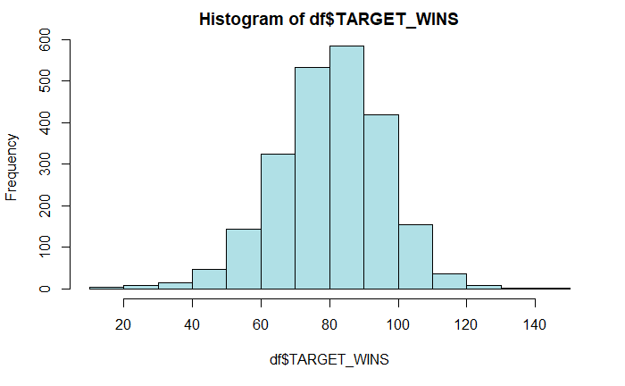

```r
hist(df$TARGET_WINS, col = 'powderblue')
```

```r
skewness(df$TARGET_WINS)
```

```
[1] -0.3521437
```

```r
kurtosis(df$TARGET_WINS)
```

```
[1] 0.8125948
```

Target_Wins features negative skewness (heavy left tail) and positive kurtosis (peaked).

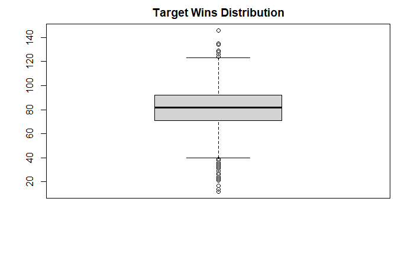

```r
boxplot(df$TARGET_WINS,
main = 'Target Wins Distribution')
```

```r
data_cor <- cor(df[ , colnames(df) != "TARGET_WINS"],  # Calculate correlations
                df$TARGET_WINS)


data_cor[order(data_cor[1]),]
```

```
          X
-0.02134966
```

Let’s look at the distribution of values in TEAM_BATTING_H

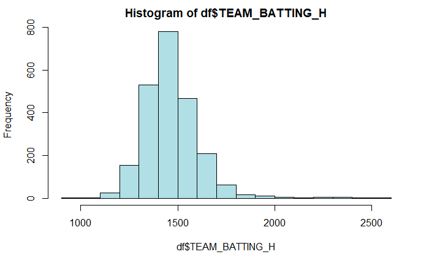

```r
hist(df$TEAM_BATTING_H, col = 'powderblue')
```

```r
skewness(df$TEAM_BATTING_H)
```

```
[1] 1.610819
```

```r
kurtosis(df$TEAM_BATTING_H)
```

```
[1] 7.29474
```

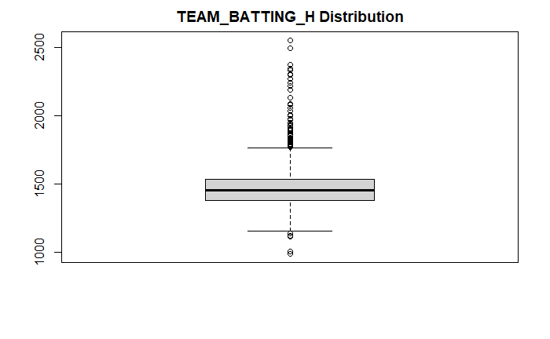

```r
boxplot(df$TEAM_BATTING_H,
main = 'TEAM_BATTING_H Distribution')
```

```r
NA
NA
```

This has significant skewness and kurtosis - transformations may improve model performance. Now let’s look at the negatively correlated column TEAM_FIELDING_E.

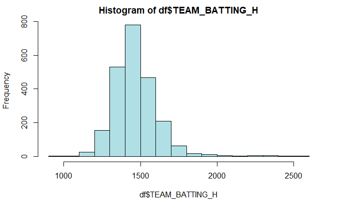

```r
hist(df$TEAM_BATTING_H, col = 'powderblue')
```

```r
skewness(df$TEAM_FIELDING_E)
```

```
[1] 2.934265
```

```r
kurtosis(df$TEAM_FIELDING_E)
```

```
[1] 10.41684
```

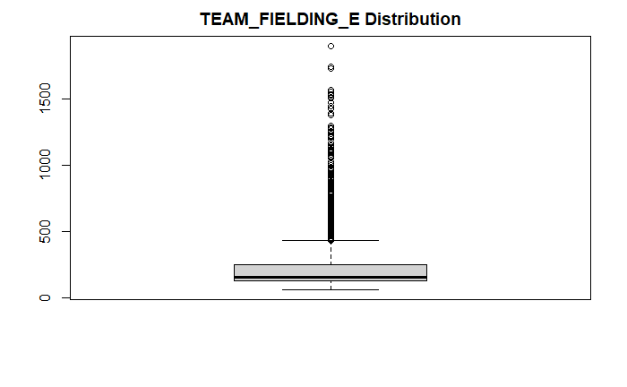

```r
boxplot(df$TEAM_FIELDING_E,
main = 'TEAM_FIELDING_E Distribution')
```

This column has many extreme upper outliers.

Now lets look at the distribution of all columns before proceeding to modeling.

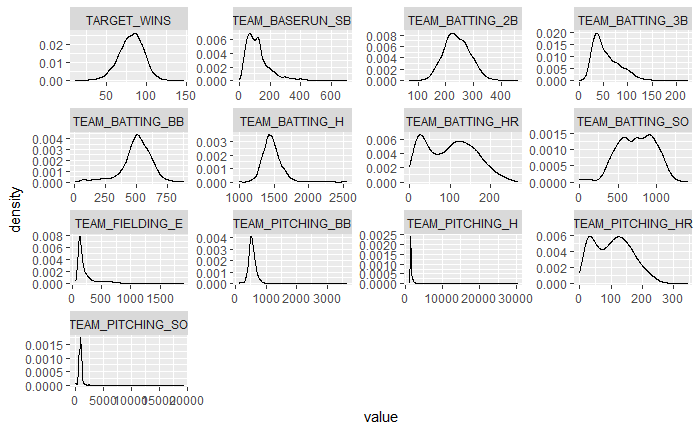

```r
#Generate a plot of all predictors


ggplot(gather(df[, 3:15], variable, value), aes(x=value)) + geom_density() +
  facet_wrap(~variable, scales = "free")
```

```r
NA
NA
```

### Modeling

Lets look at a linear model with top correlations. Note Team_Batting_2b and Team_Batting_H are moderately correlated, so I will not include team_batting_2b

```r
summary(lr_md1 <- lm(TARGET_WINS ~ TEAM_BATTING_H + TEAM_BATTING_3B + TEAM_BATTING_BB, data = df))
```

```
Call:
lm(formula = TARGET_WINS ~ TEAM_BATTING_H + TEAM_BATTING_3B +
    TEAM_BATTING_BB, data = df)

Residuals:
    Min      1Q  Median      3Q     Max
-61.962  -8.712   0.424   9.281  49.130

Coefficients:
                Estimate Std. Error t value Pr(>|t|)
(Intercept)     0.672292   3.331717   0.202  0.84010
TEAM_BATTING_H  0.041435   0.002236  18.530  < 2e-16 ***
TEAM_BATTING_3B 0.031554   0.012029   2.623  0.00877 **
TEAM_BATTING_BB 0.034916   0.002494  14.002  < 2e-16 ***
---
Signif. codes:  0 ‘***’ 0.001 ‘**’ 0.01 ‘*’ 0.05 ‘.’ 0.1 ‘ ’ 1

Residual standard error: 13.88 on 2271 degrees of freedom
Multiple R-squared:  0.2154,    Adjusted R-squared:  0.2143
F-statistic: 207.8 on 3 and 2271 DF,  p-value: < 2.2e-16
```

```r
summary(lr_md1 <- lm(TARGET_WINS ~ TEAM_BATTING_H + TEAM_BATTING_3B + TEAM_BATTING_BB + TEAM_PITCHING_HR + TEAM_FIELDING_E + TEAM_PITCHING_SO + TEAM_PITCHING_H, data = df))
```

```
Call:
lm(formula = TARGET_WINS ~ TEAM_BATTING_H + TEAM_BATTING_3B +
    TEAM_BATTING_BB + TEAM_PITCHING_HR + TEAM_FIELDING_E + TEAM_PITCHING_SO +
    TEAM_PITCHING_H, data = df)

Residuals:
    Min      1Q  Median      3Q     Max
-50.050  -8.794   0.127   8.867  51.034

Coefficients:
                   Estimate Std. Error t value Pr(>|t|)
(Intercept)       3.2058423  3.8366765   0.836 0.403480
TEAM_BATTING_H    0.0453369  0.0027380  16.558  < 2e-16 ***
TEAM_BATTING_3B   0.1078234  0.0156920   6.871 8.19e-12 ***
TEAM_BATTING_BB   0.0123301  0.0031899   3.865 0.000114 ***
TEAM_PITCHING_HR  0.0234181  0.0069676   3.361 0.000789 ***
TEAM_FIELDING_E  -0.0141444  0.0023272  -6.078 1.42e-09 ***
TEAM_PITCHING_SO  0.0024381  0.0006382   3.820 0.000137 ***
TEAM_PITCHING_H  -0.0012122  0.0003463  -3.500 0.000474 ***
---
Signif. codes:  0 ‘***’ 0.001 ‘**’ 0.01 ‘*’ 0.05 ‘.’ 0.1 ‘ ’ 1

Residual standard error: 13.5 on 2267 degrees of freedom
Multiple R-squared:   0.26, Adjusted R-squared:  0.2577
F-statistic: 113.8 on 7 and 2267 DF,  p-value: < 2.2e-16
```

Let’s see a model with all columns

```r
summary(lr_md1 <- lm(TARGET_WINS ~ . - X - INDEX, data = df))
```

```
Call:
lm(formula = TARGET_WINS ~ . - X - INDEX, data = df)

Residuals:
    Min      1Q  Median      3Q     Max
-51.569  -8.886   0.096   8.647  56.879

Coefficients:
                   Estimate Std. Error t value Pr(>|t|)
(Intercept)       9.3056230  5.2272412   1.780  0.07517 .
TEAM_BATTING_H    0.0482103  0.0038927  12.385  < 2e-16 ***
TEAM_BATTING_2B  -0.0231153  0.0093696  -2.467  0.01370 *
TEAM_BATTING_3B   0.0676231  0.0170697   3.962 7.68e-05 ***
TEAM_BATTING_HR   0.0396335  0.0277699   1.427  0.15366
TEAM_BATTING_BB   0.0034307  0.0061528   0.558  0.57719
TEAM_BATTING_SO  -0.0060280  0.0025862  -2.331  0.01985 *
TEAM_BASERUN_SB   0.0348005  0.0043842   7.938 3.21e-15 ***
TEAM_PITCHING_H  -0.0008899  0.0004343  -2.049  0.04056 *
TEAM_PITCHING_HR  0.0118177  0.0248054   0.476  0.63382
TEAM_PITCHING_BB  0.0006691  0.0044686   0.150  0.88099
TEAM_PITCHING_SO  0.0026856  0.0009362   2.869  0.00416 **
TEAM_FIELDING_E  -0.0215927  0.0024662  -8.756  < 2e-16 ***
---
Signif. codes:  0 ‘***’ 0.001 ‘**’ 0.01 ‘*’ 0.05 ‘.’ 0.1 ‘ ’ 1

Residual standard error: 13.28 on 2262 degrees of freedom
Multiple R-squared:  0.2846,    Adjusted R-squared:  0.2808
F-statistic:    75 on 12 and 2262 DF,  p-value: < 2.2e-16
```

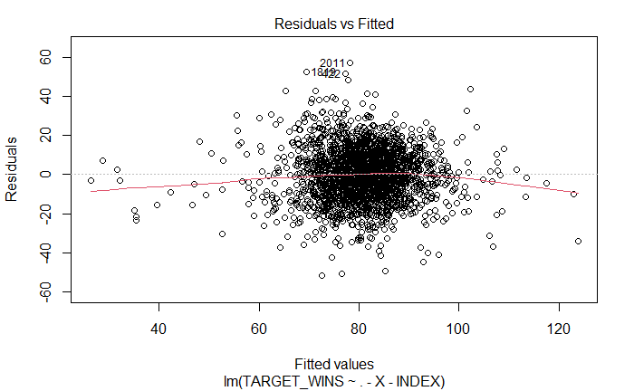

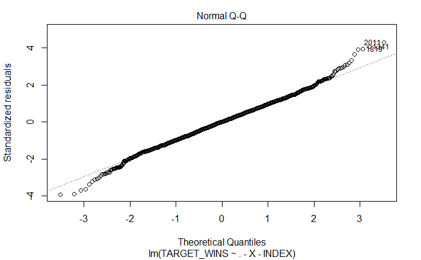

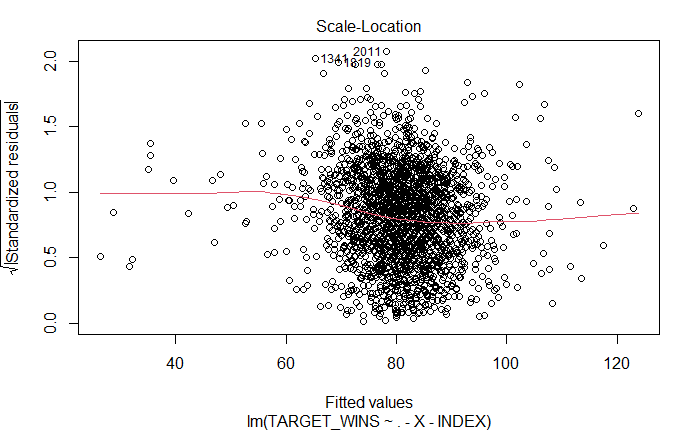

```r
plot(lr_md1)
```

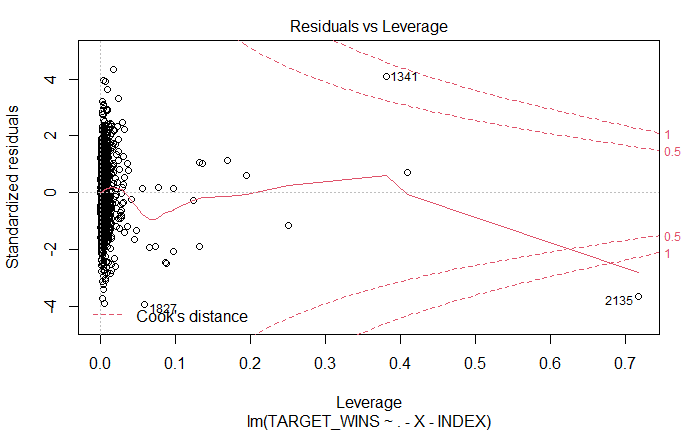

```r
NA
```

Most assumptions are broken here - errors are not normal on both tails, scale-location trend line is not straight.

Let’s see how a log-10 transformation of target_wins changes performance

```r
summary(lr_md2 <- lm(log10(TARGET_WINS) ~ . - X - INDEX, data = df))
```

```
Call:
lm(formula = log10(TARGET_WINS) ~ . - X - INDEX, data = df)

Residuals:
     Min       1Q   Median       3Q      Max
-0.52184 -0.04648  0.00554  0.05025  0.26014

Coefficients:
                   Estimate Std. Error t value Pr(>|t|)
(Intercept)       1.449e+00  3.104e-02  46.668  < 2e-16 ***
TEAM_BATTING_H    3.221e-04  2.312e-05  13.933  < 2e-16 ***
TEAM_BATTING_2B  -1.654e-04  5.564e-05  -2.972 0.002993 **
TEAM_BATTING_3B   3.721e-04  1.014e-04   3.671 0.000247 ***
TEAM_BATTING_HR   9.465e-05  1.649e-04   0.574 0.566098
TEAM_BATTING_BB  -3.111e-05  3.654e-05  -0.851 0.394712
TEAM_BATTING_SO  -1.363e-05  1.536e-05  -0.888 0.374841
TEAM_BASERUN_SB   1.985e-04  2.604e-05   7.622 3.65e-14 ***
TEAM_PITCHING_H  -1.305e-05  2.579e-06  -5.060 4.53e-07 ***
TEAM_PITCHING_HR  1.331e-04  1.473e-04   0.904 0.366274
TEAM_PITCHING_BB  4.378e-05  2.654e-05   1.650 0.099145 .
TEAM_PITCHING_SO  1.444e-05  5.560e-06   2.598 0.009450 **
TEAM_FIELDING_E  -1.637e-04  1.465e-05 -11.177  < 2e-16 ***
---
Signif. codes:  0 ‘***’ 0.001 ‘**’ 0.01 ‘*’ 0.05 ‘.’ 0.1 ‘ ’ 1

Residual standard error: 0.07889 on 2262 degrees of freedom
Multiple R-squared:  0.324, Adjusted R-squared:  0.3204
F-statistic: 90.35 on 12 and 2262 DF,  p-value: < 2.2e-16
```

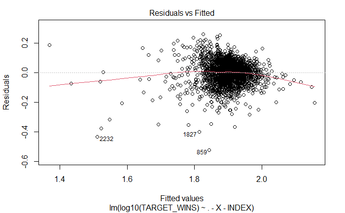

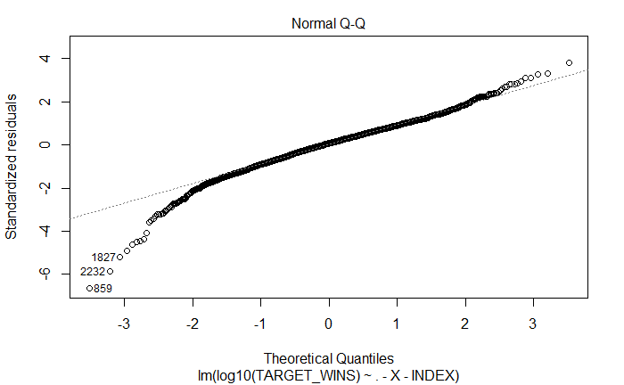

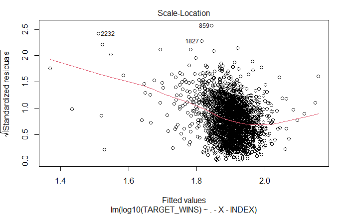

```r
plot(lr_md2)
```

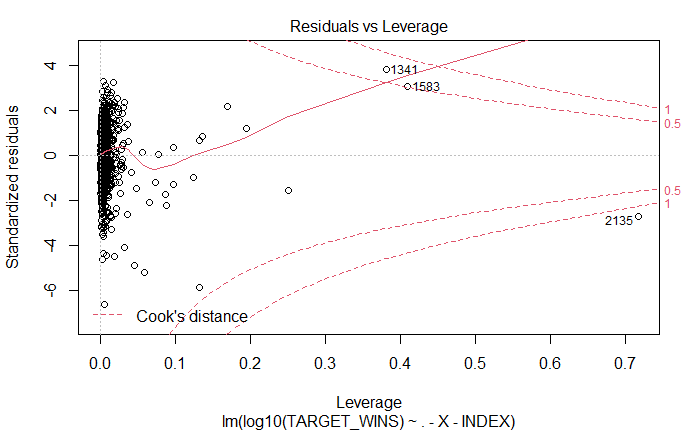

```r
NA
```

I’m going with “lr_md2” as my final model.

### Prediction and Model Summary

```r
test <- read.csv("moneyball_test.csv")

head(test)
```

|  | X | INDEX | TEAM_BATTING_H | TEAM_BATTING_2B | TEAM_BATTING_3B | TEAM_BATTING_HR | TEAM_BATTING_BB | TEAM_BATTING_SO | TEAM_BASERUN_SB | TEAM_BASERUN_CS | TEAM_BATTING_HBP | TEAM_PITCHING_H | TEAM_PITCHING_HR | TEAM_PITCHING_BB | TEAM_PITCHING_SO | TEAM_FIELDING_E | TEAM_FIELDING_DP |
| --- | --- | --- | --- | --- | --- | --- | --- | --- | --- | --- | --- | --- | --- | --- | --- | --- | --- |
| 1 | 0 | 9 | 1209 | 170 | 33 | 83 | 447 | 1080 | 62 | 50 | NA | 1209 | 83 | 447 | 1080 | 140 | 156 |
| 2 | 1 | 10 | 1221 | 151 | 29 | 88 | 516 | 929 | 54 | 39 | NA | 1221 | 88 | 516 | 929 | 135 | 164 |
| 3 | 2 | 14 | 1395 | 183 | 29 | 93 | 509 | 816 | 59 | 47 | NA | 1395 | 93 | 509 | 816 | 156 | 153 |
| 4 | 3 | 47 | 1539 | 309 | 29 | 159 | 486 | 914 | 148 | 57 | 42 | 1539 | 159 | 486 | 914 | 124 | 154 |
| 5 | 4 | 60 | 1445 | 203 | 68 | 5 | 95 | 416 | NA | NA | NA | 3902 | 14 | 257 | 1123 | 616 | 130 |
| 6 | 5 | 63 | 1431 | 236 | 53 | 10 | 215 | 377 | NA | NA | NA | 2793 | 20 | 420 | 736 | 572 | 105 |

```r
summary(test)
```

```
       X             INDEX      TEAM_BATTING_H TEAM_BATTING_2B TEAM_BATTING_3B  TEAM_BATTING_HR  TEAM_BATTING_BB
 Min.   :  0.0   Min.   :   9   Min.   : 819   Min.   : 44.0   Min.   : 14.00   Min.   :  0.00   Min.   : 15.0
 1st Qu.: 64.5   1st Qu.: 708   1st Qu.:1387   1st Qu.:210.0   1st Qu.: 35.00   1st Qu.: 44.50   1st Qu.:436.5
 Median :129.0   Median :1249   Median :1455   Median :239.0   Median : 52.00   Median :101.00   Median :509.0
 Mean   :129.0   Mean   :1264   Mean   :1469   Mean   :241.3   Mean   : 55.91   Mean   : 95.63   Mean   :499.0
 3rd Qu.:193.5   3rd Qu.:1832   3rd Qu.:1548   3rd Qu.:278.5   3rd Qu.: 72.00   3rd Qu.:135.50   3rd Qu.:565.5
 Max.   :258.0   Max.   :2525   Max.   :2170   Max.   :376.0   Max.   :155.00   Max.   :242.00   Max.   :792.0

 TEAM_BATTING_SO  TEAM_BASERUN_SB TEAM_BASERUN_CS  TEAM_BATTING_HBP TEAM_PITCHING_H TEAM_PITCHING_HR TEAM_PITCHING_BB
 Min.   :   0.0   Min.   :  0.0   Min.   :  0.00   Min.   :42.00    Min.   : 1155   Min.   :  0.0    Min.   : 136.0
 1st Qu.: 545.0   1st Qu.: 59.0   1st Qu.: 38.00   1st Qu.:53.50    1st Qu.: 1426   1st Qu.: 52.0    1st Qu.: 471.0
 Median : 686.0   Median : 92.0   Median : 49.50   Median :62.00    Median : 1515   Median :104.0    Median : 526.0
 Mean   : 709.3   Mean   :123.7   Mean   : 52.32   Mean   :62.37    Mean   : 1813   Mean   :102.1    Mean   : 552.4
 3rd Qu.: 912.0   3rd Qu.:151.8   3rd Qu.: 63.00   3rd Qu.:67.50    3rd Qu.: 1681   3rd Qu.:142.5    3rd Qu.: 606.5
 Max.   :1268.0   Max.   :580.0   Max.   :154.00   Max.   :96.00    Max.   :22768   Max.   :336.0    Max.   :2008.0
 NA's   :18       NA's   :13      NA's   :87       NA's   :240
 TEAM_PITCHING_SO TEAM_FIELDING_E  TEAM_FIELDING_DP
 Min.   :   0.0   Min.   :  73.0   Min.   : 69.0
 1st Qu.: 613.0   1st Qu.: 131.0   1st Qu.:131.0
 Median : 745.0   Median : 163.0   Median :148.0
 Mean   : 799.7   Mean   : 249.7   Mean   :146.1
 3rd Qu.: 938.0   3rd Qu.: 252.0   3rd Qu.:164.0
 Max.   :9963.0   Max.   :1568.0   Max.   :204.0
 NA's   :18                        NA's   :31
```

Apply same transformations to test dataset

```r
dim(test)
```

```
[1] 259  17
```

```r
test = subset(test, select = -c(TEAM_BASERUN_CS, TEAM_BATTING_HBP, TEAM_FIELDING_DP) )

dim(test)
```

```
[1] 259  14
```

```r
names(which(colSums(is.na(test))>0))
```

```
[1] "TEAM_BATTING_SO"  "TEAM_BASERUN_SB"  "TEAM_PITCHING_SO"
```

```r
for(i in 1:ncol(test)) {
  test[ , i][is.na(test[ , i])] <- mean(test[ , i], na.rm=TRUE)
}

names(which(colSums(is.na(test))>0))
```

```
character(0)
```

Time to predict with test data.

```r
preds <- 10^(predict(lr_md2, test))
```

```r
submit <- data_frame('Index' = test$INDEX, 'P_TARGET_WINS' = preds)
```

```
`data_frame()` was deprecated in tibble 1.1.0.
Please use `tibble()` instead.
```

```r
write_csv(submit, 'submission1.csv')
```

```r
library(MASS)
#Return Model Equation

cc <- lr_md2$coefficients
(eqn <- paste("Y =", paste(round(cc[1],5), paste(round(cc[-1],5), names(cc[-1]), sep=" * ", collapse=" + "), sep=" + "), "+ e"))
```

[output not shown]

```r
lr_md2$coefficients
```

```
     (Intercept)   TEAM_BATTING_H  TEAM_BATTING_2B  TEAM_BATTING_3B  TEAM_BATTING_HR  TEAM_BATTING_BB  TEAM_BATTING_SO
    1.448738e+00     3.220954e-04    -1.653547e-04     3.721186e-04     9.464634e-05    -3.110531e-05    -1.363261e-05
 TEAM_BASERUN_SB  TEAM_PITCHING_H TEAM_PITCHING_HR TEAM_PITCHING_BB TEAM_PITCHING_SO  TEAM_FIELDING_E
    1.984527e-04    -1.305044e-05     1.331217e-04     4.378008e-05     1.444176e-05    -1.636950e-04
```

```r
summary(lr_md2)
```

```
Call:
lm(formula = log10(TARGET_WINS) ~ . - X - INDEX, data = df)

Residuals:
     Min       1Q   Median       3Q      Max
-0.52184 -0.04648  0.00554  0.05025  0.26014

Coefficients:
                   Estimate Std. Error t value Pr(>|t|)
(Intercept)       1.449e+00  3.104e-02  46.668  < 2e-16 ***
TEAM_BATTING_H    3.221e-04  2.312e-05  13.933  < 2e-16 ***
TEAM_BATTING_2B  -1.654e-04  5.564e-05  -2.972 0.002993 **
TEAM_BATTING_3B   3.721e-04  1.014e-04   3.671 0.000247 ***
TEAM_BATTING_HR   9.465e-05  1.649e-04   0.574 0.566098
TEAM_BATTING_BB  -3.111e-05  3.654e-05  -0.851 0.394712
TEAM_BATTING_SO  -1.363e-05  1.536e-05  -0.888 0.374841
TEAM_BASERUN_SB   1.985e-04  2.604e-05   7.622 3.65e-14 ***
TEAM_PITCHING_H  -1.305e-05  2.579e-06  -5.060 4.53e-07 ***
TEAM_PITCHING_HR  1.331e-04  1.473e-04   0.904 0.366274
TEAM_PITCHING_BB  4.378e-05  2.654e-05   1.650 0.099145 .
TEAM_PITCHING_SO  1.444e-05  5.560e-06   2.598 0.009450 **
TEAM_FIELDING_E  -1.637e-04  1.465e-05 -11.177  < 2e-16 ***
---
Signif. codes:  0 ‘***’ 0.001 ‘**’ 0.01 ‘*’ 0.05 ‘.’ 0.1 ‘ ’ 1

Residual standard error: 0.07889 on 2262 degrees of freedom
Multiple R-squared:  0.324, Adjusted R-squared:  0.3204
F-statistic: 90.35 on 12 and 2262 DF,  p-value: < 2.2e-16
```

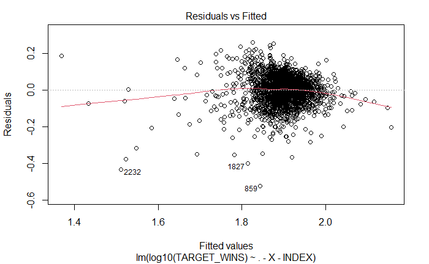

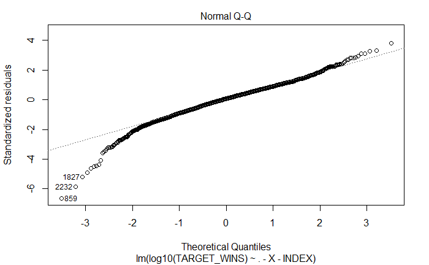

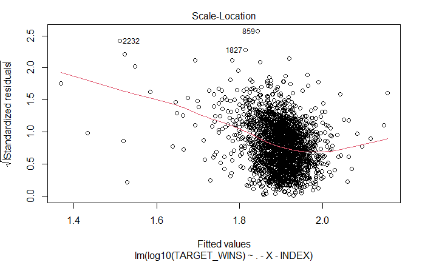

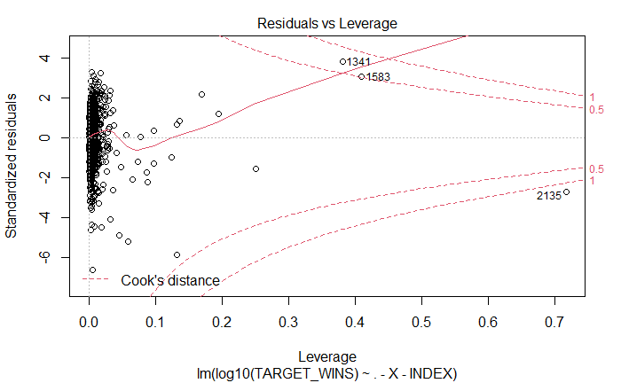

```r
plot(lr_md2)
```

## Assignment 2 Items start Here

```r
head(df)
```

|  | X | INDEX | TARGET_WINS | TEAM_BATTING_H | TEAM_BATTING_2B | TEAM_BATTING_3B | TEAM_BATTING_HR | TEAM_BATTING_BB | TEAM_BATTING_SO | TEAM_BASERUN_SB | TEAM_PITCHING_H | TEAM_PITCHING_HR | TEAM_PITCHING_BB | TEAM_PITCHING_SO | TEAM_FIELDING_E |
| --- | --- | --- | --- | --- | --- | --- | --- | --- | --- | --- | --- | --- | --- | --- | --- |
| 1 | 0 | 1 | 39 | 1445 | 194 | 39 | 13 | 143 | 842 | 124.82 | 9364 | 84 | 927 | 5456 | 1011 |
| 2 | 1 | 2 | 70 | 1339 | 219 | 22 | 190 | 685 | 1075 | 37.00 | 1347 | 191 | 689 | 1082 | 193 |
| 3 | 2 | 3 | 86 | 1377 | 232 | 35 | 137 | 602 | 917 | 46.00 | 1377 | 137 | 602 | 917 | 175 |
| 4 | 3 | 4 | 70 | 1387 | 209 | 38 | 96 | 451 | 922 | 43.00 | 1396 | 97 | 454 | 928 | 164 |
| 5 | 4 | 5 | 82 | 1297 | 186 | 27 | 102 | 472 | 920 | 49.00 | 1297 | 102 | 472 | 920 | 138 |
| 6 | 5 | 6 | 75 | 1279 | 200 | 36 | 92 | 443 | 973 | 107.00 | 1279 | 92 | 443 | 973 | 123 |

```r
dim(df)
```

```
[1] 2275   15
```

```r
df_2 <- df

df_2$residuals <- (lr_md1$residuals)

head(df_2)
```

|  | X | INDEX | TARGET_WINS | TEAM_BATTING_H | TEAM_BATTING_2B | TEAM_BATTING_3B | TEAM_BATTING_HR | TEAM_BATTING_BB | TEAM_BATTING_SO | TEAM_BASERUN_SB | TEAM_PITCHING_H | TEAM_PITCHING_HR | TEAM_PITCHING_BB | TEAM_PITCHING_SO | TEAM_FIELDING_E | residuals |
| --- | --- | --- | --- | --- | --- | --- | --- | --- | --- | --- | --- | --- | --- | --- | --- | --- |
| 1 | 0 | 1 | 39 | 1445 | 194 | 39 | 13 | 143 | 842 | 124.82 | 9364 | 84 | 927 | 5456 | 1011 | -24.498453 |
| 2 | 1 | 2 | 70 | 1339 | 219 | 22 | 190 | 685 | 1075 | 37.00 | 1347 | 191 | 689 | 1082 | 193 | -5.230382 |
| 3 | 2 | 3 | 86 | 1377 | 232 | 35 | 137 | 602 | 917 | 46.00 | 1377 | 137 | 602 | 917 | 175 | 10.256239 |
| 4 | 3 | 4 | 70 | 1387 | 209 | 38 | 96 | 451 | 922 | 43.00 | 1396 | 97 | 454 | 928 | 164 | -4.361262 |
| 5 | 4 | 5 | 82 | 1297 | 186 | 27 | 102 | 472 | 920 | 49.00 | 1297 | 102 | 472 | 920 | 138 | 10.959998 |
| 6 | 5 | 6 | 75 | 1279 | 200 | 36 | 92 | 443 | 973 | 107.00 | 1279 | 92 | 443 | 973 | 123 | 2.995000 |

```r
NA
```

Split into buckets

If TARGET_WINS <50 bucket = one If TARGET_WINS >= 50 and TARGET_WINS <100 bucket = two If TARGET_WINS >= 100 bucket = three

```r
df_2 <- df_2 %>% mutate(Bucket =
                     case_when(TARGET_WINS < 50 ~ "one",
                               TARGET_WINS >= 50 & TARGET_WINS < 100 ~ "two",
                               TARGET_WINS >= 100 ~ "three")
)

aggregate(TARGET_WINS~Bucket, data=df_2, mean)
```

| Bucket | TARGET_WINS |
| --- | --- |
| one | 39.66667 |
| three | 106.31579 |
| two | 79.26401 |

```r
NA
```

Make a boxplot of the residuals by bucket. Which bucket gives a better fit? Do you have buckets that are consistently overpredicted? Do you have buckets that are consistently under-predicted?

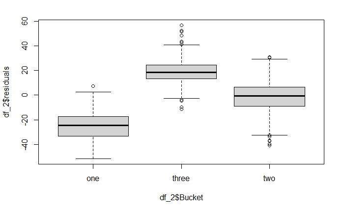

```r
boxplot(df_2$residuals ~ df_2$Bucket)
```

The mean of the residuals in bucket two appears closest to zero, indicating my model performs best on these records.

```r
df_2$lr_md1_predictions <- df_2$TARGET_WINS - df_2$residuals

head(df_2)
```

|  | X | INDEX | TARGET_WINS | TEAM_BATTING_H | TEAM_BATTING_2B | TEAM_BATTING_3B | TEAM_BATTING_HR | TEAM_BATTING_BB | TEAM_BATTING_SO | TEAM_BASERUN_SB | TEAM_PITCHING_H | TEAM_PITCHING_HR | TEAM_PITCHING_BB | TEAM_PITCHING_SO | TEAM_FIELDING_E | residuals | Bucket | lr_md1_predictions |
| --- | --- | --- | --- | --- | --- | --- | --- | --- | --- | --- | --- | --- | --- | --- | --- | --- | --- | --- |
| 1 | 0 | 1 | 39 | 1445 | 194 | 39 | 13 | 143 | 842 | 124.82 | 9364 | 84 | 927 | 5456 | 1011 | -24.498453 | one | 63.49845 |
| 2 | 1 | 2 | 70 | 1339 | 219 | 22 | 190 | 685 | 1075 | 37.00 | 1347 | 191 | 689 | 1082 | 193 | -5.230382 | two | 75.23038 |
| 3 | 2 | 3 | 86 | 1377 | 232 | 35 | 137 | 602 | 917 | 46.00 | 1377 | 137 | 602 | 917 | 175 | 10.256239 | two | 75.74376 |
| 4 | 3 | 4 | 70 | 1387 | 209 | 38 | 96 | 451 | 922 | 43.00 | 1396 | 97 | 454 | 928 | 164 | -4.361262 | two | 74.36126 |
| 5 | 4 | 5 | 82 | 1297 | 186 | 27 | 102 | 472 | 920 | 49.00 | 1297 | 102 | 472 | 920 | 138 | 10.959998 | two | 71.04000 |
| 6 | 5 | 6 | 75 | 1279 | 200 | 36 | 92 | 443 | 973 | 107.00 | 1279 | 92 | 443 | 973 | 123 | 2.995000 | two | 72.00500 |

```r
x1 = as.data.frame(aggregate(TARGET_WINS~Bucket, data=df_2, mean))
x2 = as.data.frame(aggregate(lr_md1_predictions~Bucket, data=df_2, mean))

x1$Pred_wins = x2$lr_md1_predictions

x1$mean_diff = x1$TARGET_WINS - x1$Pred_wins

x1
```

| Bucket | TARGET_WINS | Pred_wins | mean_diff |
| --- | --- | --- | --- |
| one | 39.66667 | 64.52701 | -24.860340 |
| three | 106.31579 | 87.23773 | 19.078058 |
| two | 79.26401 | 80.63151 | -1.367499 |

```r
NA
NA
```

Predictions for group two are more accurate.

Group TARGET_WINS using dummy or indicator variables. Create between 3 and 6 groups. Code a family of indicator variables for the TARGET_WINS groups to include in your multiple regression model. See Chapter 5 p131 in C&H. Your indicator variables should be of the form Group1 = 1 if TARGET_WINS is in some range, Group1 = 0 otherwise.

```r
summary(df_2$TARGET_WINS)
```

```
   Min. 1st Qu.  Median    Mean 3rd Qu.    Max.
  12.00   71.00   82.00   80.83   92.00  146.00
```

```r
(146 - 12)/4
```

```
[1] 33.5
```

```r
x = 146

i = 1

for (i in 1:4){
  print(146 - i*34)

}
```

```
[1] 112
[1] 78
[1] 44
[1] 10
```

```r
df_2$wins_cat <- cut(df_2$TARGET_WINS,
              breaks=c(10, 44, 78, 112, 147),
              labels=c('1', '2', '3', '4'))

head(df_2)
```

[output not shown]

```r
# Install the required package
install.packages("fastDummies")
# Load the library
library(fastDummies)
```

```r
data <- dummy_cols(df_2,
                   select_columns = "wins_cat", remove_first_dummy = TRUE)

head(data)
```

|  | X | INDEX | TARGET_WINS | TEAM_BATTING_H | TEAM_BATTING_2B | TEAM_BATTING_3B | TEAM_BATTING_HR | TEAM_BATTING_BB | TEAM_BATTING_SO | TEAM_BASERUN_SB | TEAM_PITCHING_H | TEAM_PITCHING_HR | TEAM_PITCHING_BB | TEAM_PITCHING_SO | TEAM_FIELDING_E | residuals | wins_cat | wins_cat_2 | wins_cat_3 | wins_cat_4 |
| --- | --- | --- | --- | --- | --- | --- | --- | --- | --- | --- | --- | --- | --- | --- | --- | --- | --- | --- | --- | --- |
| 1 | 0 | 1 | 39 | 1445 | 194 | 39 | 13 | 143 | 842 | 124.82 | 9364 | 84 | 927 | 5456 | 1011 | -24.498453 | 1 | 0 | 0 | 0 |
| 2 | 1 | 2 | 70 | 1339 | 219 | 22 | 190 | 685 | 1075 | 37.00 | 1347 | 191 | 689 | 1082 | 193 | -5.230382 | 2 | 1 | 0 | 0 |
| 3 | 2 | 3 | 86 | 1377 | 232 | 35 | 137 | 602 | 917 | 46.00 | 1377 | 137 | 602 | 917 | 175 | 10.256239 | 3 | 0 | 1 | 0 |
| 4 | 3 | 4 | 70 | 1387 | 209 | 38 | 96 | 451 | 922 | 43.00 | 1396 | 97 | 454 | 928 | 164 | -4.361262 | 2 | 1 | 0 | 0 |
| 5 | 4 | 5 | 82 | 1297 | 186 | 27 | 102 | 472 | 920 | 49.00 | 1297 | 102 | 472 | 920 | 138 | 10.959998 | 3 | 0 | 1 | 0 |
| 6 | 5 | 6 | 75 | 1279 | 200 | 36 | 92 | 443 | 973 | 107.00 | 1279 | 92 | 443 | 973 | 123 | 2.995000 | 2 | 1 | 0 | 0 |

Refit regression model with new dummy variables. My base category is win_cat 1, the lowest wins category group.

```r
summary(lr_md3 <- lm(TARGET_WINS ~ . - X - INDEX - residuals - wins_cat, data = data))
```

```
Call:
lm(formula = TARGET_WINS ~ . - X - INDEX - residuals - wins_cat,
    data = data)

Residuals:
     Min       1Q   Median       3Q      Max
-24.4915  -5.6152   0.0109   5.6333  23.2909

Coefficients:
                   Estimate Std. Error t value Pr(>|t|)
(Intercept)      16.6169101  3.2711977   5.080 4.09e-07 ***
TEAM_BATTING_H    0.0154087  0.0023238   6.631 4.16e-11 ***
TEAM_BATTING_2B  -0.0057626  0.0054046  -1.066   0.2864
TEAM_BATTING_3B   0.0052001  0.0098787   0.526   0.5987
TEAM_BATTING_HR   0.0086846  0.0161342   0.538   0.5904
TEAM_BATTING_BB  -0.0006955  0.0035727  -0.195   0.8457
TEAM_BATTING_SO  -0.0026263  0.0015015  -1.749   0.0804 .
TEAM_BASERUN_SB   0.0137629  0.0025444   5.409 7.00e-08 ***
TEAM_PITCHING_H  -0.0001111  0.0002583  -0.430   0.6673
TEAM_PITCHING_HR  0.0086313  0.0143451   0.602   0.5474
TEAM_PITCHING_BB  0.0013525  0.0025921   0.522   0.6019
TEAM_PITCHING_SO  0.0012668  0.0005417   2.339   0.0194 *
TEAM_FIELDING_E  -0.0062423  0.0014734  -4.237 2.36e-05 ***
wins_cat_2       29.2387672  1.4921667  19.595  < 2e-16 ***
wins_cat_3       50.3269743  1.5082436  33.368  < 2e-16 ***
wins_cat_4       75.7032549  1.9995958  37.859  < 2e-16 ***
---
Signif. codes:  0 ‘***’ 0.001 ‘**’ 0.01 ‘*’ 0.05 ‘.’ 0.1 ‘ ’ 1

Residual standard error: 7.649 on 2259 degrees of freedom
Multiple R-squared:  0.7631,    Adjusted R-squared:  0.7615
F-statistic: 485.1 on 15 and 2259 DF,  p-value: < 2.2e-16
```

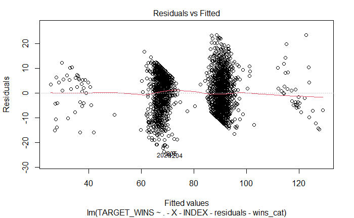

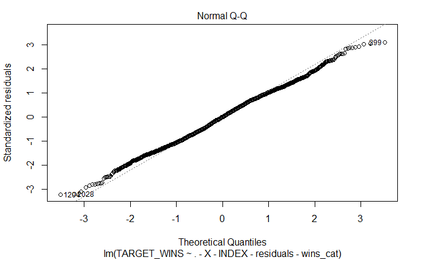

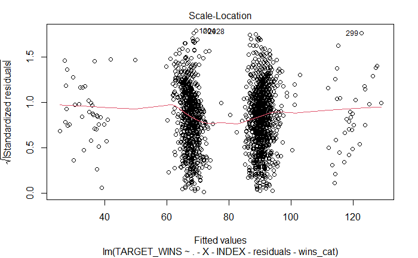

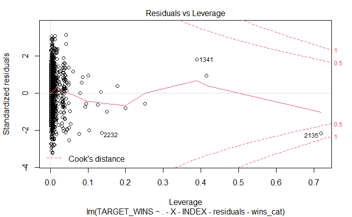

```r
plot(lr_md3)
```

The Adjusted R-squared value jumped up a lot, which makes sense after feeding the response in as dummy predictor variables.

Define a new variable called trunc_team_batting as: trunc_team_batting = team_batting_h if team_batting_h < 1122 then trunc_team_batting_h=1122 if team_batting_h > 2333 then trunc_team_batting_h=2333

```r
data2 <- data %>% mutate(trunc_team_batting =
                     case_when(TEAM_BATTING_H < 1122 ~ '1122',
                               TEAM_BATTING_H >= 1122 & TEAM_BATTING_H <= 2333 ~ '1',
                               TEAM_BATTING_H > 2333 ~ '2333')
)

head(data2)
```

|  | X | INDEX | TARGET_WINS | TEAM_BATTING_H | TEAM_BATTING_2B | TEAM_BATTING_3B | TEAM_BATTING_HR | TEAM_BATTING_BB | TEAM_BATTING_SO | TEAM_BASERUN_SB | TEAM_PITCHING_H | TEAM_PITCHING_HR | TEAM_PITCHING_BB | TEAM_PITCHING_SO | TEAM_FIELDING_E | residuals | wins_cat | wins_cat_2 | wins_cat_3 | wins_cat_4 | trunc_team_batting |
| --- | --- | --- | --- | --- | --- | --- | --- | --- | --- | --- | --- | --- | --- | --- | --- | --- | --- | --- | --- | --- | --- |
| 1 | 0 | 1 | 39 | 1445 | 194 | 39 | 13 | 143 | 842 | 124.82 | 9364 | 84 | 927 | 5456 | 1011 | -24.498453 | 1 | 0 | 0 | 0 | 1 |
| 2 | 1 | 2 | 70 | 1339 | 219 | 22 | 190 | 685 | 1075 | 37.00 | 1347 | 191 | 689 | 1082 | 193 | -5.230382 | 2 | 1 | 0 | 0 | 1 |
| 3 | 2 | 3 | 86 | 1377 | 232 | 35 | 137 | 602 | 917 | 46.00 | 1377 | 137 | 602 | 917 | 175 | 10.256239 | 3 | 0 | 1 | 0 | 1 |
| 4 | 3 | 4 | 70 | 1387 | 209 | 38 | 96 | 451 | 922 | 43.00 | 1396 | 97 | 454 | 928 | 164 | -4.361262 | 2 | 1 | 0 | 0 | 1 |
| 5 | 4 | 5 | 82 | 1297 | 186 | 27 | 102 | 472 | 920 | 49.00 | 1297 | 102 | 472 | 920 | 138 | 10.959998 | 3 | 0 | 1 | 0 | 1 |
| 6 | 5 | 6 | 75 | 1279 | 200 | 36 | 92 | 443 | 973 | 107.00 | 1279 | 92 | 443 | 973 | 123 | 2.995000 | 2 | 1 | 0 | 0 | 1 |

```r
NA
```

```r
summary(data2$trunc_team_batting)
```

```
   Length     Class      Mode
     2275 character character
```

Make dummies from trunc_team_batting?

```r
data3 <- dummy_cols(data2,
                   select_columns = "trunc_team_batting")

head(data3)
```

|  | X | INDEX | TARGET_WINS | TEAM_BATTING_H | TEAM_BATTING_2B | TEAM_BATTING_3B | TEAM_BATTING_HR | TEAM_BATTING_BB | TEAM_BATTING_SO | TEAM_BASERUN_SB | TEAM_PITCHING_H | TEAM_PITCHING_HR | TEAM_PITCHING_BB | TEAM_PITCHING_SO | TEAM_FIELDING_E | residuals | wins_cat | wins_cat_2 | wins_cat_3 | wins_cat_4 | trunc_team_batting | trunc_team_batting_1 | trunc_team_batting_1122 | trunc_team_batting_2333 |
| --- | --- | --- | --- | --- | --- | --- | --- | --- | --- | --- | --- | --- | --- | --- | --- | --- | --- | --- | --- | --- | --- | --- | --- | --- |
| 1 | 0 | 1 | 39 | 1445 | 194 | 39 | 13 | 143 | 842 | 124.82 | 9364 | 84 | 927 | 5456 | 1011 | -24.498453 | 1 | 0 | 0 | 0 | 1 | 1 | 0 | 0 |
| 2 | 1 | 2 | 70 | 1339 | 219 | 22 | 190 | 685 | 1075 | 37.00 | 1347 | 191 | 689 | 1082 | 193 | -5.230382 | 2 | 1 | 0 | 0 | 1 | 1 | 0 | 0 |
| 3 | 2 | 3 | 86 | 1377 | 232 | 35 | 137 | 602 | 917 | 46.00 | 1377 | 137 | 602 | 917 | 175 | 10.256239 | 3 | 0 | 1 | 0 | 1 | 1 | 0 | 0 |
| 4 | 3 | 4 | 70 | 1387 | 209 | 38 | 96 | 451 | 922 | 43.00 | 1396 | 97 | 454 | 928 | 164 | -4.361262 | 2 | 1 | 0 | 0 | 1 | 1 | 0 | 0 |
| 5 | 4 | 5 | 82 | 1297 | 186 | 27 | 102 | 472 | 920 | 49.00 | 1297 | 102 | 472 | 920 | 138 | 10.959998 | 3 | 0 | 1 | 0 | 1 | 1 | 0 | 0 |
| 6 | 5 | 6 | 75 | 1279 | 200 | 36 | 92 | 443 | 973 | 107.00 | 1279 | 92 | 443 | 973 | 123 | 2.995000 | 2 | 1 | 0 | 0 | 1 | 1 | 0 | 0 |

```r
summary(lr_md4 <- lm(TARGET_WINS ~ . - X - INDEX - residuals - wins_cat - trunc_team_batting - trunc_team_batting_1, data = data3))
```

```
Call:
lm(formula = TARGET_WINS ~ . - X - INDEX - residuals - wins_cat -
    trunc_team_batting - trunc_team_batting_1, data = data3)

Residuals:
    Min      1Q  Median      3Q     Max
-24.530  -5.614   0.033   5.638  23.363

Coefficients:
                          Estimate Std. Error t value Pr(>|t|)
(Intercept)              1.772e+01  3.402e+00   5.208 2.08e-07 ***
TEAM_BATTING_H           1.477e-02  2.398e-03   6.158 8.71e-10 ***
TEAM_BATTING_2B         -5.384e-03  5.429e-03  -0.992  0.32141
TEAM_BATTING_3B          6.743e-03  9.932e-03   0.679  0.49728
TEAM_BATTING_HR          7.999e-03  1.637e-02   0.489  0.62506
TEAM_BATTING_BB          8.061e-04  3.639e-03   0.222  0.82472
TEAM_BATTING_SO         -3.420e-03  1.565e-03  -2.186  0.02894 *
TEAM_BASERUN_SB          1.418e-02  2.554e-03   5.554 3.13e-08 ***
TEAM_PITCHING_H          1.551e-05  2.653e-04   0.058  0.95338
TEAM_PITCHING_HR         1.013e-02  1.450e-02   0.698  0.48495
TEAM_PITCHING_BB        -9.037e-05  2.678e-03  -0.034  0.97308
TEAM_PITCHING_SO         1.819e-03  6.025e-04   3.019  0.00256 **
TEAM_FIELDING_E         -6.505e-03  1.478e-03  -4.402 1.12e-05 ***
wins_cat_2               2.880e+01  1.509e+00  19.088  < 2e-16 ***
wins_cat_3               4.987e+01  1.525e+00  32.702  < 2e-16 ***
wins_cat_4               7.535e+01  2.015e+00  37.401  < 2e-16 ***
trunc_team_batting_1122 -1.147e+01  5.423e+00  -2.114  0.03460 *
trunc_team_batting_2333 -9.019e-01  4.175e+00  -0.216  0.82900
---
Signif. codes:  0 ‘***’ 0.001 ‘**’ 0.01 ‘*’ 0.05 ‘.’ 0.1 ‘ ’ 1

Residual standard error: 7.645 on 2257 degrees of freedom
Multiple R-squared:  0.7636,    Adjusted R-squared:  0.7618
F-statistic: 428.8 on 17 and 2257 DF,  p-value: < 2.2e-16
```

## Section 2 Model Comparison of Y versus log(Y)

Before proceeding, I’m dropping the wins cat fields from my dataframe as that data won’t be available in the test set

```r
dim(data3)
```

```
[1] 2275   24
```

```r
df = subset(data3, select = -c(residuals, wins_cat, wins_cat_2, wins_cat_3, wins_cat_4, trunc_team_batting, trunc_team_batting_1) )

dim(df)
```

```
[1] 2275   17
```

```r
head(df)
```

|  | X | INDEX | TARGET_WINS | TEAM_BATTING_H | TEAM_BATTING_2B | TEAM_BATTING_3B | TEAM_BATTING_HR | TEAM_BATTING_BB | TEAM_BATTING_SO | TEAM_BASERUN_SB | TEAM_PITCHING_H | TEAM_PITCHING_HR | TEAM_PITCHING_BB | TEAM_PITCHING_SO | TEAM_FIELDING_E | trunc_team_batting_1122 | trunc_team_batting_2333 |
| --- | --- | --- | --- | --- | --- | --- | --- | --- | --- | --- | --- | --- | --- | --- | --- | --- | --- |
| 1 | 0 | 1 | 39 | 1445 | 194 | 39 | 13 | 143 | 842 | 124.82 | 9364 | 84 | 927 | 5456 | 1011 | 0 | 0 |
| 2 | 1 | 2 | 70 | 1339 | 219 | 22 | 190 | 685 | 1075 | 37.00 | 1347 | 191 | 689 | 1082 | 193 | 0 | 0 |
| 3 | 2 | 3 | 86 | 1377 | 232 | 35 | 137 | 602 | 917 | 46.00 | 1377 | 137 | 602 | 917 | 175 | 0 | 0 |
| 4 | 3 | 4 | 70 | 1387 | 209 | 38 | 96 | 451 | 922 | 43.00 | 1396 | 97 | 454 | 928 | 164 | 0 | 0 |
| 5 | 4 | 5 | 82 | 1297 | 186 | 27 | 102 | 472 | 920 | 49.00 | 1297 | 102 | 472 | 920 | 138 | 0 | 0 |
| 6 | 5 | 6 | 75 | 1279 | 200 | 36 | 92 | 443 | 973 | 107.00 | 1279 | 92 | 443 | 973 | 123 | 0 | 0 |

```r
NA
NA
```